# Lab 3A - Regression

### 1. Load the Data

1. Import the OS library.

```python
import os
```

2. Set the working directory.

```python
os.chdir("C:\\Workshop\\Data")
```

3. Import the pandas library as "pd".

```python
import pandas as pd
```

4. Read the Iris CSV file into a data frame called *iris*.

```python
iris = pd.read_csv("Iris.csv")
```

### 2. Explore the Data

1. Inspect the *iris* data set.

```python
iris.head()
```

|  | Sepal_Length | Sepal_Width | Petal_Length | Petal_Width | Species |
| --- | --- | --- | --- | --- | --- |
| 0 | 5.1 | 3.5 | 1.4 | 0.2 | setosa |
| 1 | 4.9 | 3.0 | 1.4 | 0.2 | setosa |
| 2 | 4.7 | 3.2 | 1.3 | 0.2 | setosa |
| 3 | 4.6 | 3.1 | 1.5 | 0.2 | setosa |
| 4 | 5.0 | 3.6 | 1.4 | 0.2 | setosa |

2. Import the matplotlib pyplot library as "plt".

```python
import matplotlib.pyplot as plt
```

3. Create a scatterplot matrix of the *iris* data set.  
*Note: The semicolon at the end prevents text output from being displayed with the plot.*

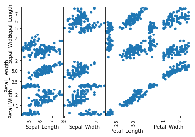

```python
pd.plotting.scatter_matrix(
    frame = iris,
    alpha = 1,
    s = 100,
    diagonal = 'none');
```

6. Create a correlation matrix of the *iris* data set.

```python
correlations = iris.corr()

print(correlations)
```

```
              Sepal_Length  Sepal_Width  Petal_Length  Petal_Width
Sepal_Length      1.000000    -0.117570      0.871754     0.817941
Sepal_Width      -0.117570     1.000000     -0.428440    -0.366126
Petal_Length      0.871754    -0.428440      1.000000     0.962865
Petal_Width       0.817941    -0.366126      0.962865     1.000000
```

5. Import the seaborn library as "sns".

```python
import seaborn as sns
```

6. Create a correlogram using the correlation matrix.

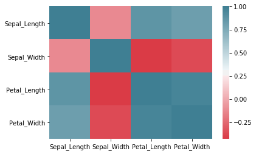

```python
sns.heatmap(
    data = correlations,
    cmap = sns.diverging_palette(
        h_neg = 10,
        h_pos = 220,
        as_cmap=True));
```

7. Question: Which variable is most strongly correlated with Petal Width?

8. Get the correlation between petal length and width.

```python
iris.Petal_Length \
    .corr(iris.Petal_Width)
```

```
0.9628654314027961
```

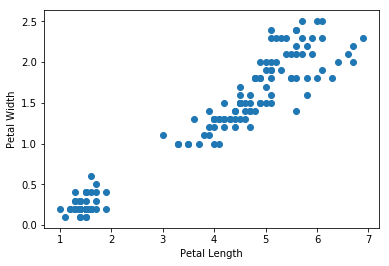

```python
plt.scatter(
    x = iris.Petal_Length,
    y = iris.Petal_Width)
plt.xlabel("Petal Length")
plt.ylabel("Petal Width")
plt.show()
```

### 3. Transform the Data

1. Inspect the *iris* data set.

```python
iris.head()
```

|  | Sepal_Length | Sepal_Width | Petal_Length | Petal_Width | Species |
| --- | --- | --- | --- | --- | --- |
| 0 | 5.1 | 3.5 | 1.4 | 0.2 | setosa |
| 1 | 4.9 | 3.0 | 1.4 | 0.2 | setosa |
| 2 | 4.7 | 3.2 | 1.3 | 0.2 | setosa |
| 3 | 4.6 | 3.1 | 1.5 | 0.2 | setosa |
| 4 | 5.0 | 3.6 | 1.4 | 0.2 | setosa |

2. Create a data frame named *X* containing all variables except for petal width.

```python
X = iris.iloc[:, iris.columns != "Petal_Width"]
```

3. Inspect the features *X*.

```python
X.head()
```

|  | Sepal_Length | Sepal_Width | Petal_Length | Species |
| --- | --- | --- | --- | --- |
| 0 | 5.1 | 3.5 | 1.4 | setosa |
| 1 | 4.9 | 3.0 | 1.4 | setosa |
| 2 | 4.7 | 3.2 | 1.3 | setosa |
| 3 | 4.6 | 3.1 | 1.5 | setosa |
| 4 | 5.0 | 3.6 | 1.4 | setosa |

4. Convert the categorical variable *Species* into a set of one-hot-encoding variables.

```python
dummies = pd.get_dummies(X.Species)
```

5. Inspect the one-hot encoded variables.

```python
dummies.head()
```

|  | setosa | versicolor | virginica |
| --- | --- | --- | --- |
| 0 | 1 | 0 | 0 |
| 1 | 1 | 0 | 0 |
| 2 | 1 | 0 | 0 |
| 3 | 1 | 0 | 0 |
| 4 | 1 | 0 | 0 |

6. Append the one-hot-encoded species variables to the features data set *X*.

```python
X = pd.concat([X, dummies], axis = 1)
```

7. Drop the *Species* column from the features data frame *X*.

```python
X = X.drop("Species", 1)
```

8. Inspect the features data frame *X*.

```python
X.head()
```

|  | Sepal_Length | Sepal_Width | Petal_Length | setosa | versicolor | virginica |
| --- | --- | --- | --- | --- | --- | --- |
| 0 | 5.1 | 3.5 | 1.4 | 1 | 0 | 0 |
| 1 | 4.9 | 3.0 | 1.4 | 1 | 0 | 0 |
| 2 | 4.7 | 3.2 | 1.3 | 1 | 0 | 0 |
| 3 | 4.6 | 3.1 | 1.5 | 1 | 0 | 0 |
| 4 | 5.0 | 3.6 | 1.4 | 1 | 0 | 0 |

9. Create a series named *y* containing just the labels (i.e. Petal_Width).

```python
y = iris.Petal_Width
```

10. Inspect the series of labels *y*.

```python
y.head()
```

```
0    0.2
1    0.2
2    0.2
3    0.2
4    0.2
Name: Petal_Width, dtype: float64
```

### 4. Create the Training and Test Set

1. Import the numpy library as "np".

```python
import numpy as np
```

2. Set the random number seed to 234.

```python
np.random.seed(234)
```

3. Import the test_train_split function from sklearn.

```python
from sklearn.model_selection import train_test_split
```

4. Randomly sample 80% of the rows for the training set and 20% of the rows for the test set.

```python
X_train, X_test, y_train, y_test = train_test_split(
    X,
    y,
    train_size = 0.80,
    test_size = 0.20)
```

5. Inspect the shape of the training and test sets using the `shape` property.

```python
print("X_train: ", X_train.shape)
print("y_train: ", y_train.shape)
print("X_test:  ", X_test.shape)
print("y_test:  ", y_test.shape)
```

```
X_train:  (120, 6)
y_train:  (120,)
X_test:   (30, 6)
y_test:   (30,)
```

### 5. Predict with Simple Linear Regression

1. Import the linear regression class from sklearn.

```python
from sklearn.linear_model import LinearRegression
```

2. Create a simple linear regression model.

```python
simple_model = LinearRegression()
```

3. Create a data frame named *x1_train* containing only the petal length feature from the training set.

```python
x1_train = X_train.loc[:, ["Petal_Length"]]
```

4. Create a data frame named x1_test containing onl the petal length feature from the test set.

```python
x1_test = X_test.loc[:, ["Petal_Length"]]
```

5. Train the model using the training data.  
*Note: You should be using x1_train as your training data.*

```python
simple_model.fit(
    X = x1_train,
    y = y_train)
```

```
LinearRegression(copy_X=True, fit_intercept=True, n_jobs=1, normalize=False)
```

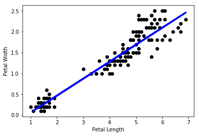

```python
plt.scatter(
    x = iris.Petal_Length,
    y = iris.Petal_Width,
    color = "black")
plt.plot(
    x1_test,
    simple_model.predict(
        x1_test),
    color = "blue",
    linewidth = 3)
plt.xlabel("Petal Length")
plt.ylabel("Petal Width")
plt.show()
```

7. Inspect the slope (*m*) and y-intercept (*b*) parameter estimates.

```python
print("y-intercept (b): ", simple_model.intercept_)
print("Slope (m):        ", simple_model.coef_[0])
```

```
y-intercept (b):  -0.3486959626278219
Slope (m):         0.40736325883164276
```

8. Question: How do you interpret these two values?

9. Predict the labels of the test set using the model.

```python
simple_predictions = simple_model.predict(x1_test)
```

10. Visualize the prediction error.

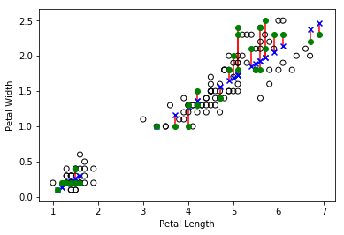

```python
# Plot the training set (black dots)
plt.scatter(
    x = x1_train.Petal_Length,
    y = y_train,
    color = "black",
    facecolor = "none")

# Plot the predictions (blue dots)
plt.scatter(
    x = x1_test.Petal_Length,
    y = simple_predictions,
    color = "blue",
    marker = 'x')

# Plot the correct answer (green dots)
plt.scatter(
    x = x1_test.Petal_Length,
    y = y_test,
    color = "green")

# Plot the error (red lines)
plt.plot(
    [x1_test.Petal_Length, x1_test.Petal_Length],
    [simple_predictions, y_test],
    color = "red",
    zorder = 0)

# Finish the plot
plt.xlabel("Petal Length")
plt.ylabel("Petal Width")
plt.show()
```

11. Question: How do you interpret this graph?

12. Compute the root mean squared error (RMSE) the these predictions.

```python
simple_rmse = np.sqrt(np.mean((y_test - simple_predictions) ** 2))

print(simple_rmse)
```

```
0.24794604821207347
```

### 6. Predict with Multiple Linear Regression

1. Create a linear regression model.

```python
multiple_model = LinearRegression()
```

2. Train the model using all features of the training data.

```python
multiple_model.fit(
    X = X_train,
    y = y_train)
```

```
LinearRegression(copy_X=True, fit_intercept=True, n_jobs=1, normalize=False)
```

3. Inspect the parameter estimates.

```python
print("{:<12}: {: .3f}"
    .format("y-intercept", multiple_model.intercept_))

for i, column_name in enumerate(X_train.columns):
    print("{:<12}: {: .3f}".format(
        column_name,
        multiple_model.coef_[i]))
```

```
y-intercept :  0.108
Sepal_Length: -0.116
Sepal_Width :  0.270
Petal_Length:  0.249
setosa      : -0.564
versicolor  :  0.103
virginica   :  0.461
```

4. Question: How do you interpret these values?

5. Predict output values for the input values in the test set.

```python
multiple_predictions = multiple_model.predict(X_test)
```

6. Visualize the prediction error.

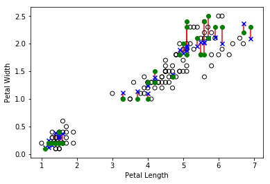

```python
plt.scatter(
    x = X_train.Petal_Length,
    y = y_train,
    color = "black",
    facecolor = "none")
plt.scatter(
    x = X_test.Petal_Length,
    y = multiple_predictions,
    color = "blue",
    marker = 'x')
plt.scatter(
    x = X_test.Petal_Length,
    y = y_test,
    color = "green")
plt.plot(
    [X_test.Petal_Length, X_test.Petal_Length],
    [multiple_predictions, y_test],
    color = "red",
    zorder = 0)
plt.xlabel("Petal Length")
plt.ylabel("Petal Width")
plt.show()
```

7. Question: How do you interpret this graph?

8. Compute the root mean squared error (RMSE) of these predictions.

```python
multiple_rmse = np.sqrt(np.mean((y_test - multiple_predictions) ** 2))

print(multiple_rmse)
```

```
0.20398495060494315
```

9. How do you interpret this value?

### 7. Predict with a Neural Network Regressor

1. Import the standard scaler from sklearn.

```python
from sklearn.preprocessing import StandardScaler
```

```python
X_scaler = StandardScaler()
y_scaler = StandardScaler()
```

```python
X_scaler.fit(X)
y_scaler.fit(y.values.reshape(-1, 1))
```

```
StandardScaler(copy=True, with_mean=True, with_std=True)
```

4. Scale the training and test data.

```python
X_train_scaled = X_scaler.transform(X_train)
X_test_scaled = X_scaler.transform(X_test)
y_train_scaled = y_scaler.transform(y_train.values.reshape(-1, 1))
y_test_scaled = y_scaler.transform(y_test.values.reshape(-1, 1))
```

5. Import the neural network regressor class from sklearn.

```python
from sklearn.neural_network import MLPRegressor
```

6. Create a neural network regressor with 4 hidden nodes, a tanh activation function, an LBFGS solver, and 1000 maximum iterations.

```python
neural_model = MLPRegressor(
    hidden_layer_sizes = (4),
    activation = "tanh",
    solver = "lbfgs",
    max_iter = 1000)
```

7. Train the model with the training set.

```python
neural_model.fit(
    X = X_train_scaled,
    y = y_train_scaled.reshape(-1, ))
```

```
MLPRegressor(activation='tanh', alpha=0.0001, batch_size='auto', beta_1=0.9,
       beta_2=0.999, early_stopping=False, epsilon=1e-08,
       hidden_layer_sizes=4, learning_rate='constant',
       learning_rate_init=0.001, max_iter=1000, momentum=0.9,
       nesterovs_momentum=True, power_t=0.5, random_state=None,
       shuffle=True, solver='lbfgs', tol=0.0001, validation_fraction=0.1,
       verbose=False, warm_start=False)
```

8. Predict output values for the test set.

```python
scaled_predictions = neural_model.predict(X_test_scaled)
```

9. Unscale the predictions.

```python
neural_predictions = y_scaler.inverse_transform(scaled_predictions)
```

10. Visualize the prediction error.

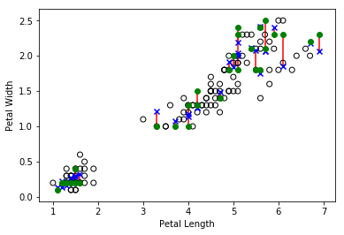

```python
plt.scatter(
    x = X_train.Petal_Length,
    y = y_train,
    color = "black",
    facecolor = "none")
plt.scatter(
    x = X_test.Petal_Length,
    y = neural_predictions,
    color = "blue",
    marker = 'x')
plt.scatter(
    x = X_test.Petal_Length,
    y = y_test,
    color = "green")
plt.plot(
    [X_test.Petal_Length, X_test.Petal_Length],
    [neural_predictions, y_test],
    color = "red",
    zorder = 0)
plt.xlabel("Petal Length")
plt.ylabel("Petal Width")
plt.show()
```

11. Compute the root mean squared error (RMSE) of these predictions.

```python
neural_rmse = np.sqrt(np.mean((y_test - neural_predictions) ** 2))
```

12. Inspect the RMSE of these predictions.

```python
print(neural_rmse)
```

```
0.18341008377583856
```

### 8. Evaluate the Regressors

1. Compare all three results.

```python
print("Simple RMSE:   ", simple_rmse)
print("Multiple RMSE: ", multiple_rmse)
print("Neural RMSE:   ", neural_rmse)
```

```
Simple RMSE:    0.24794604821207347
Multiple RMSE:  0.20398495060494315
Neural RMSE:    0.18341008377583856
```

2. Question: Which of these models would you choose? Why?